# Group Comparison

2024-09-04

## Importing Data

### Task Performance Data

```r
NumberLetter_HC <- read.csv("Z:/Projekte_Meinke/Old_projects/Labrotation_Rebecca/Daten_Gruppenvergleich/NumberLetter_HC.csv")
NumberLetter_Patients_Post <- read.csv("Z:/Projekte_Meinke/Old_projects/Labrotation_Rebecca/Daten_Gruppenvergleich/NumberLetter_Patients_Post.csv")
NumberLetter_Patients_Pre <-  read.csv("Z:/Projekte_Meinke/Old_projects/Labrotation_Rebecca/Daten_Gruppenvergleich/NumberLetter_Patients_Pre.csv")

Stroop_HC <- read.csv("Z:/Projekte_Meinke/Old_projects/Labrotation_Rebecca/Daten_Gruppenvergleich/Stroop_HC.csv")
Stroop_Patients_Post <-  read.csv("Z:/Projekte_Meinke/Old_projects/Labrotation_Rebecca/Daten_Gruppenvergleich/Stroop_Patients_Post.csv")
Stroop_Patients_Pre <-  read.csv("Z:/Projekte_Meinke/Old_projects/Labrotation_Rebecca/Daten_Gruppenvergleich/Stroop_Patients_Pre.csv")

TwoBack_HC <- read.csv("Z:/Projekte_Meinke/Old_projects/Labrotation_Rebecca/Daten_Gruppenvergleich/TwoBack_HC.csv")
TwoBack_Patients_Post <-  read.csv("Z:/Projekte_Meinke/Old_projects/Labrotation_Rebecca/Daten_Gruppenvergleich/TwoBack_Patients_Post.csv")
TwoBack_Patients_Pre <-  read.csv("Z:/Projekte_Meinke/Old_projects/Labrotation_Rebecca/Daten_Gruppenvergleich/TwoBack_Patients_Pre.csv")
```

### Subject Data

```r
data_all <- haven::read_dta('Z:/Projekte_Meinke/Old_projects/Labrotation_Rebecca/CognitiveControl_Treatment/Data_Kevin_28.07.23.dta')
colnames(data_all)[which(colnames(data_all) == "id")] <- "Subject"
```

## Comparison HC vs. Patients

### Prepare dataset

```r
# Merge patients and controls
## 1. Merge patients Pre (different tasks)
Patients_pre_2 <- merge(NumberLetter_Patients_Pre, Stroop_Patients_Pre, by = "Subject")
Patients_pre_3 <- merge(Patients_pre_2, TwoBack_Patients_Pre, by = "Subject")

## 2. Merge controls (different tasks)
Controls_2 <- merge(NumberLetter_HC, Stroop_HC, by = "Subject")
Controls_3 <- merge(Controls_2, TwoBack_HC, by = "Subject")

## 3. Merge Controls and patients
Patients_vs_HC <- rbind(Patients_pre_3, Controls_3)

## 4. Reduce dataset to BIS columns
BIS_columns <- colnames(Patients_vs_HC)[startsWith(colnames(Patients_vs_HC), "BIS")]
Patients_vs_HC_imp <- Patients_vs_HC[,c("Subject",BIS_columns,"Gruppe")]

## 5. Add better names
Patients_vs_HC_imp <- Patients_vs_HC_imp %>%
  rename(NumberLetter_BIS_Repeat = BIS_Repeat,
         NumberLetter_BIS_Switch = BIS_Switch,
         Stroop_BIS_Congruent = BIS_Congruent,
         Stroop_BIS_Incongruent = BIS_Incongruent,
         TwoBack_BIS_Total = BIS_Total,
         TwoBack_BIS_Target = BIS_Target,
         TwoBack_BIS_Foil = BIS_Foil)

BIS_columns_renamed <- grep("BIS", colnames(Patients_vs_HC_imp), value = TRUE)

## 6. Add confounds (Alter, Geschlecht, Abschluss)
Patients_vs_HC_imp_conf <- merge(data_all[,c("Subject","Alter","Geschlecht","Abschluss")], Patients_vs_HC_imp, by = "Subject")
```

Data for 89 patients and 85 healthy controls were available. Find assumption test for normality in script “Testing Normality”

### Calculate Welch t-test

```r
t_test_mult_cols <- function(df_basis, cols) {
  df <- data.frame(t_statistic = numeric(length(cols)), p_value = numeric(length(cols)),
                   group_mean_Patients = numeric(length(cols)), sd_Patients = numeric(length(cols)),
                   group_mean_HC = numeric(length(cols)), sd_HC = numeric(length(cols)),
                   cohen_d = numeric(length(cols)))
  rownames(df) <- cols
  for (col in cols) {
    # Using the non-formula interface
    group0 <- df_basis[df_basis[["Gruppe"]] == 0, col]
    group1 <- df_basis[df_basis[["Gruppe"]] == 1, col]
    results <- t.test(group0, group1, paired = FALSE, var.equal = FALSE)
    #Alternativ using formula method:
      #results <- t.test(df_basis[[col]] ~ df_basis[["Gruppe"]], paired = FALSE, var.equal = FALSE)

    # Calculate Cohen's d using the cohen.d function (effect size)
    cohen_d_result <- cohen.d(group0, group1, hedges.correction = FALSE)
    cohen_d <- cohen_d_result$estimate

    # Calculate power using pwr.t.test (Bonferroni=0.007?; two-sided?)
    n0 <- length(group0)
    n1 <- length (group1)
    power_result <- pwr.t.test(d = cohen_d, n = min(n0, n1), sig.level = 0.05, type = "two.sample", alternative = "greater")
    power <- power_result$power

    # Store the results
    df[col, "t_statistic"] <- round(results$statistic, 2)
    df[col, "p_value"] <- round(results$p.value, 2)
    df[col, "group_mean_Patients"] <- round(mean(group0), 2)
    df[col, "sd_Patients"] <- round(sd(group0), 2)
    df[col, "group_mean_HC"] <- round(mean(group1), 2)
    df[col, "sd_HC"] <- round(sd(group1), 2)
    df[col, "cohen_d"] <- round(cohen_d, 2)
    df[col, "power"] <- round(power, 2)
  }
  return(df)
}

t_test_table <- t_test_mult_cols(df_basis = Patients_vs_HC_imp, cols = BIS_columns_renamed)
pander(t_test_table, style = "rmarkdown", fontsize = "tiny")
```

Table continues below

|  | t_statistic | p_value | group_mean_Patients |
| --- | --- | --- | --- |
| **NumberLetter_BIS_Repeat** | 2.33 | 0.02 | 0.95 |
| **NumberLetter_BIS_Switch** | 2.28 | 0.02 | -1 |
| **Stroop_BIS_Congruent** | 2.72 | 0.01 | 0.8 |
| **Stroop_BIS_Incongruent** | 2.18 | 0.03 | -0.83 |
| **TwoBack_BIS_Total** | 1.4 | 0.16 | 0 |
| **TwoBack_BIS_Target** | 1.55 | 0.12 | -0.19 |
| **TwoBack_BIS_Foil** | 1.2 | 0.23 | 0.06 |

Table continues below

|  | sd_Patients | group_mean_HC | sd_HC |
| --- | --- | --- | --- |
| **NumberLetter_BIS_Repeat** | 1.43 | 0.22 | 2.59 |
| **NumberLetter_BIS_Switch** | 1.98 | -1.87 | 2.98 |
| **Stroop_BIS_Congruent** | 1.35 | -0.08 | 2.75 |
| **Stroop_BIS_Incongruent** | 1.46 | -1.51 | 2.55 |
| **TwoBack_BIS_Total** | 1.57 | -0.33 | 1.57 |
| **TwoBack_BIS_Target** | 1.4 | -0.55 | 1.63 |
| **TwoBack_BIS_Foil** | 1.75 | -0.26 | 1.67 |

|  | cohen_d | power |
| --- | --- | --- |
| **NumberLetter_BIS_Repeat** | 0.35 | 0.73 |
| **NumberLetter_BIS_Switch** | 0.34 | 0.72 |
| **Stroop_BIS_Congruent** | 0.41 | 0.84 |
| **Stroop_BIS_Incongruent** | 0.33 | 0.68 |
| **TwoBack_BIS_Total** | 0.21 | 0.39 |
| **TwoBack_BIS_Target** | 0.23 | 0.45 |
| **TwoBack_BIS_Foil** | 0.18 | 0.32 |

### Control Welch-test for covariates age, sex, and education

```r
#Descriptive statistics
table1 <-
  Patients_vs_HC_imp_conf %>%
  tbl_summary(include = c(Alter, Geschlecht, Abschluss), by = Gruppe)
pander(as.data.frame(table1))
```

| **Characteristic** | **0** N = 85 | **1** N = 89 |
| --- | --- | --- |
| Alter | 23 (20, 25) | 23 (20, 28) |
| Unknown | 3 | 0 |
| Geschlecht | 74 (90%) | 83 (93%) |
| Unknown | 3 | 0 |
| Abschluss | NA | NA |
| 1 | 0 (0%) | 1 (1.1%) |
| 2 | 3 (3.7%) | 22 (25%) |
| 3 | 75 (91%) | 62 (70%) |
| 4 | 4 (4.9%) | 4 (4.5%) |
| Unknown | 3 | 0 |

```r
#ANCOVA
ANCOVA_mult_cols <- function(df_basis, cols, covariates = NULL){
  # Create a overview of ANCOVA results for several columns in a dataframe
  df <- data.frame(Gruppe_p_value = numeric(length(cols)))
  rownames(df) <- cols
  for (col in cols){
    # Run ANCOVA
    formula <- paste(col, " ~ Gruppe", ifelse(length(covariates) > 0, paste(" + ", paste(covariates, collapse = " + ")), ""))
    anova_result <- aov(as.formula(formula), data = df_basis)
    coefficients <- coef(anova_result)
    summary_anova <- summary(anova_result)
    #print(summary_anova)

    # Prepare nice table to summarize the results
    df[col, "Gruppe_p_value"] <- round(summary_anova[[1]]$"Pr(>F)"[1],2)
    df[col, "Gruppe_corrected_difference"] <- round(coefficients[2],2)
    df[col, "Alter_p_value"] <- round(summary_anova[[1]]$"Pr(>F)"[2],2)
    df[col, "Geschlecht_p_value"] <- round(summary_anova[[1]]$"Pr(>F)"[3],2)
    df[col, "Abschluss_p_value"] <- round(summary_anova[[1]]$"Pr(>F)"[4],2)
  }
  return(df)
}

table_ANCOVA <- ANCOVA_mult_cols(df_basis = Patients_vs_HC_imp_conf, cols = BIS_columns_renamed, covariates = c("Alter","Geschlecht","Abschluss"))
pander(table_ANCOVA, style = "rmarkdown", fontsize = "tiny")
```

Table continues below

|  | Gruppe_p_value | Gruppe_corrected_difference |
| --- | --- | --- |
| **NumberLetter_BIS_Repeat** | 0.02 | -0.52 |
| **NumberLetter_BIS_Switch** | 0.02 | -0.55 |
| **Stroop_BIS_Congruent** | 0.01 | -0.55 |
| **Stroop_BIS_Incongruent** | 0.03 | -0.37 |
| **TwoBack_BIS_Total** | 0.19 | -0.16 |
| **TwoBack_BIS_Target** | 0.15 | -0.29 |
| **TwoBack_BIS_Foil** | 0.26 | -0.1 |

Table continues below

|  | Alter_p_value | Geschlecht_p_value |
| --- | --- | --- |
| **NumberLetter_BIS_Repeat** | 0.55 | 0.14 |
| **NumberLetter_BIS_Switch** | 0.18 | 0.11 |
| **Stroop_BIS_Congruent** | 0.06 | 0.03 |
| **Stroop_BIS_Incongruent** | 0.1 | 0.01 |
| **TwoBack_BIS_Total** | 0.01 | 0.34 |
| **TwoBack_BIS_Target** | 0.12 | 0.49 |
| **TwoBack_BIS_Foil** | 0 | 0.19 |

|  | Abschluss_p_value |
| --- | --- |
| **NumberLetter_BIS_Repeat** | 0.01 |
| **NumberLetter_BIS_Switch** | 0.01 |
| **Stroop_BIS_Congruent** | 0 |
| **Stroop_BIS_Incongruent** | 0 |
| **TwoBack_BIS_Total** | 0.6 |
| **TwoBack_BIS_Target** | 0.99 |
| **TwoBack_BIS_Foil** | 0.45 |

3 observations with missings in the covariates are automatically deleted. In the Numberletter task, the difference between patients and healthy controls remained when controlling for covariates. However, also education had a main effect on performance. In the Stroop task, the difference between patients and healthy controls also remained when contrlloing for covariates. Here, also the gender and education had a main effect on performance. There was no significant effect between patients and controls in the TwoBackTask - also not when controlling for covariates. The task types Total and Foil might mainly depend on the age.

## Comparison pre vs.post

### Prepare dataset

```r
## Merge patients pre
Patients_pre_2 <- merge(NumberLetter_Patients_Pre, Stroop_Patients_Pre, by = "Subject")
Patients_pre_3 <- merge(Patients_pre_2, TwoBack_Patients_Pre, by = "Subject")
Patients_pre_3$time <- "pre"

## Merge patients Post
Patients_post_2 <- merge(NumberLetter_Patients_Post, Stroop_Patients_Post, by = "Subject")
Patients_post_3 <- merge(Patients_post_2, TwoBack_Patients_Post, by = "Subject")
Patients_post_3$time <- "post"

# Combine data
Patients_pre_3$Subject <- Patients_pre_3$Subject + 600 # This was the ID given
Patients_pre_vs_post <- rbind(Patients_post_3, Patients_pre_3)
# Remove data if subjects had only pre-values
subject_counts <- table(Patients_pre_vs_post$Subject)
multiple_rows_subjects <- names(subject_counts)[subject_counts > 1]
Patients_pre_vs_post_clean <- Patients_pre_vs_post[Patients_pre_vs_post$Subject %in% multiple_rows_subjects, ]

# Reduce to BIS
BIS_columns <- colnames(Patients_pre_vs_post_clean)[startsWith(colnames(Patients_pre_vs_post_clean), "BIS")]
Patients_pre_vs_post_imp <- Patients_pre_vs_post_clean[,c("Subject",BIS_columns,"time")]

## Add better names
Patients_pre_vs_post_imp <- Patients_pre_vs_post_imp %>%
  rename(NumberLetter_BIS_Repeat = BIS_Repeat,
         NumberLetter_BIS_Switch = BIS_Switch,
         Stroop_BIS_Congruent = BIS_Congruent,
         Stroop_BIS_Incongruent = BIS_Incongruent,
         TwoBack_BIS_Total = BIS_Total,
         TwoBack_BIS_Target = BIS_Target,
         TwoBack_BIS_Foil = BIS_Foil)
BIS_columns_renamed <- grep("BIS", colnames(Patients_pre_vs_post_imp), value = TRUE)
```

Pre and post measures were available for 83 patients.

### Testing Assumption of dependent sample t-test: Positive correlation of measurement series

```r
#Helper function to avoid redundancy (Get pre and post data in one place for assumption and Welch test)
get_pre_post_data <- function(df_basis, col) {
  pre_data <- df_basis[df_basis[["time"]] == "pre", col]
  post_data <- df_basis[df_basis[["time"]] == "post", col]
  return(list(pre = pre_data, post = post_data))
}
```

```r
## Calculate Raw Pearson Correlation and Test Significance
calculate_correlations_and_significance <- function(df_basis, cols) {
  df <- data.frame(Correlation = numeric(length(cols)), t_statistic = numeric(length(cols)),
                   p_value = numeric(length(cols)))
  rownames(df) <- cols
  for (col in cols) {
    # Get pre and post data using the new function
    data <- get_pre_post_data(df_basis, col)
    pre_data <- data$pre
    post_data <- data$post

    # Calculate Pearson correlation
    correlation <- cor(pre_data, post_data)

    # Calculate the t-statistic for the correlation
    n <- length(pre_data)
    t_statistic <- correlation * sqrt((n - 2) / (1 - correlation^2))

    # Calculate the p-value for a one-tailed test (H_0: r ≤ 0)
    p_value <- pt(t_statistic, df = n - 2, lower.tail = FALSE)

    # Store the results
    df[col, "Correlation"] <- round(correlation, 3)
    df[col, "t_statistic"] <- round(t_statistic, 3)
    df[col, "p_value"] <- round(p_value, 3)
  }
  return(df)
}


# Apply the correlation and significance test to your data
correlation_significance_table <- calculate_correlations_and_significance(df_basis = Patients_pre_vs_post_imp, cols = BIS_columns_renamed)
pander(correlation_significance_table, style = "rmarkdown", fontsize = "tiny")
```

|  | Correlation | t_statistic | p_value |
| --- | --- | --- | --- |
| **NumberLetter_BIS_Repeat** | 0.267 | 2.499 | 0.007 |
| **NumberLetter_BIS_Switch** | 0.524 | 5.534 | 0 |
| **Stroop_BIS_Congruent** | 0.692 | 8.618 | 0 |
| **Stroop_BIS_Incongruent** | 0.706 | 8.973 | 0 |
| **TwoBack_BIS_Total** | 0.609 | 6.911 | 0 |
| **TwoBack_BIS_Target** | 0.665 | 8.008 | 0 |
| **TwoBack_BIS_Foil** | 0.591 | 6.588 | 0 |

For all tasks, the correlations of the measurement series are significantly positive. Thus, the assumption is met for all tasks.

```r
paired_t_test_mult_cols <- function(df_basis, cols) {
  df <- data.frame(t_statistic = numeric(length(cols)), p_value = numeric(length(cols)),
                   group_mean_pre = numeric(length(cols)), group_mean_post = numeric(length(cols)),
                   cohen_d = numeric(length(cols)))
  rownames(df) <- cols
  for (col in cols) {
    # Get pre and post data using get_pre_post_data helper function
    data <- get_pre_post_data(df_basis, col)
    pre_data <- data$pre
    post_data <- data$post

    # non-formula interface as before
    results <- t.test(pre_data, post_data, paired = TRUE, var.equal = FALSE)

    #Alternativ using formula method:
      #results <- t.test(df_basis[[col]] ~ df_basis[["time"]], paired = TRUE, var.equal = FALSE)

    # Calculate Cohen's d using the cohen.d function for paired samples (effect size)
    cohen_d_result <- cohen.d(post_data, pre_data, paired = TRUE)
    cohen_d <- cohen_d_result$estimate

    # Calculate power using pwr.t.test
    n <- length(pre_data)
    power_result <- pwr.t.test(d = cohen_d, n = n, sig.level = 0.05, type = "paired", alternative = "greater")
                                                              #0.007? (Bonferroni)
    power <- power_result$power

    # Store the results
    df[col, "t_statistic"] <- round(results$statistic, 2)
    df[col, "p_value"] <- round(results$p.value, 2)
    df[col, "group_mean_pre"] <- round(mean(pre_data), 2)
    df[col, "sd_pre"] <- round(sd(pre_data), 2)
    df[col, "group_mean_post"] <- round(mean(post_data), 2)
    df[col, "sd_post"] <- round(sd(post_data), 2)
    df[col, "cohen_d"] <- round(cohen_d, 2)
    df[col, "power"] <- round(power, 2)
  }
  return(df)
}

t_test_table_pre_post <- paired_t_test_mult_cols(df_basis = Patients_pre_vs_post_imp, cols = BIS_columns_renamed)
pander(t_test_table_pre_post)
```

Table continues below

|  | t_statistic | p_value | group_mean_pre |
| --- | --- | --- | --- |
| **NumberLetter_BIS_Repeat** | -3.47 | 0 | 0.22 |
| **NumberLetter_BIS_Switch** | -5 | 0 | -1.96 |
| **Stroop_BIS_Congruent** | -3.57 | 0 | -0.02 |
| **Stroop_BIS_Incongruent** | -3.99 | 0 | -1.5 |
| **TwoBack_BIS_Total** | -4.16 | 0 | -0.37 |
| **TwoBack_BIS_Target** | -4.4 | 0 | -0.59 |
| **TwoBack_BIS_Foil** | -3.94 | 0 | -0.29 |

|  | group_mean_post | cohen_d | sd_pre | sd_post | power |
| --- | --- | --- | --- | --- | --- |
| **NumberLetter_BIS_Repeat** | 1.18 | 0.46 | 2.51 | 1.4 | 0.99 |
| **NumberLetter_BIS_Switch** | -0.53 | 0.54 | 2.99 | 2.03 | 1 |
| **Stroop_BIS_Congruent** | 0.74 | 0.31 | 2.65 | 1.47 | 0.87 |
| **Stroop_BIS_Incongruent** | -0.71 | 0.34 | 2.51 | 1.57 | 0.92 |
| **TwoBack_BIS_Total** | 0.24 | 0.4 | 1.59 | 1.39 | 0.98 |
| **TwoBack_BIS_Target** | 0.03 | 0.4 | 1.64 | 1.49 | 0.97 |
| **TwoBack_BIS_Foil** | 0.33 | 0.39 | 1.7 | 1.39 | 0.97 |

Patients performed better in all measurements of executive functioning after the exposure session. This might be due to a practice effect.

## Plotting

### Comparison HC vs. patients (pre)

```r
# Reshape data from wide to long format
Patients_vs_HC_long <- Patients_vs_HC_imp %>%
  pivot_longer(cols = all_of(BIS_columns_renamed),
               names_to = "Condition",
               values_to = "BIS_Score")

# Add new task variable to keep the headers intact for faceting
Patients_vs_HC_long <- Patients_vs_HC_long %>%
  mutate(Task = case_when(
    grepl("NumberLetter", Condition) ~ "NumberLetter",
    grepl("Stroop", Condition) ~ "Stroop",
    grepl("TwoBack", Condition) ~ "TwoBack"
  ))

# Remove prefixes from Condition labels, keeping Task intact
Patients_vs_HC_long <- Patients_vs_HC_long %>%
  mutate(Condition = gsub("NumberLetter_BIS_|Stroop_BIS_|TwoBack_BIS_", "", Condition))

# Convert "Gruppe" to factor
Patients_vs_HC_long$Gruppe <- factor(Patients_vs_HC_long$Gruppe, levels = c(0, 1), labels = c("Healthy Controls", "Patients"))

# Create boxplots # TODO: try violin-plot instead
boxplots_Patients_HC <- ggplot(Patients_vs_HC_long, aes(x = Condition, y = BIS_Score, color = Gruppe)) +
  geom_boxplot(outlier.shape = NA) +
  geom_jitter(position = position_jitterdodge(),
              size = 0.7,
              shape = 21,
              fill = NA) +
  facet_wrap(~ Task, scales = "free_x") +
  #facet_grid(rows = vars(Task), scales = "free_x") +
  labs(title = "Boxplots of Task Condition by Group",
       x = "Condition",
       y = "BIS-Score",
       color = "Group")

# Create violin plots with mean
violin_plots_patients_hc <- ggplot(Patients_vs_HC_long, aes(x = Condition, y = BIS_Score, fill = Gruppe)) +
  geom_violin(position = position_dodge(width = 0.8)) +
  stat_summary(fun.data = mean_sdl, geom = "pointrange", # mult = 2 (SD) by default
               position = position_dodge(width = 0.8)) + # width = 0.65, fatten = 2
  facet_wrap(~ Task, scales = "free_x") +
  labs(title = "Violin Plots of Task Condition by Group",
       x = "Task Condition",
       y = "BIS-Score",
       fill = "Group")
```

### Boxplot: Patients vs. Healthy Controls

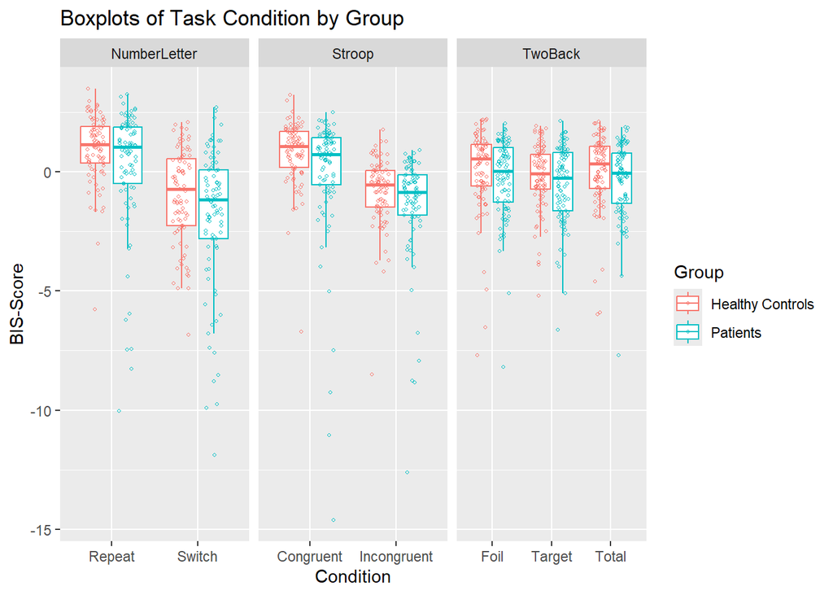

```r
print(boxplots_Patients_HC)
```

### Violin Plot: Patients vs. Healthy Controls

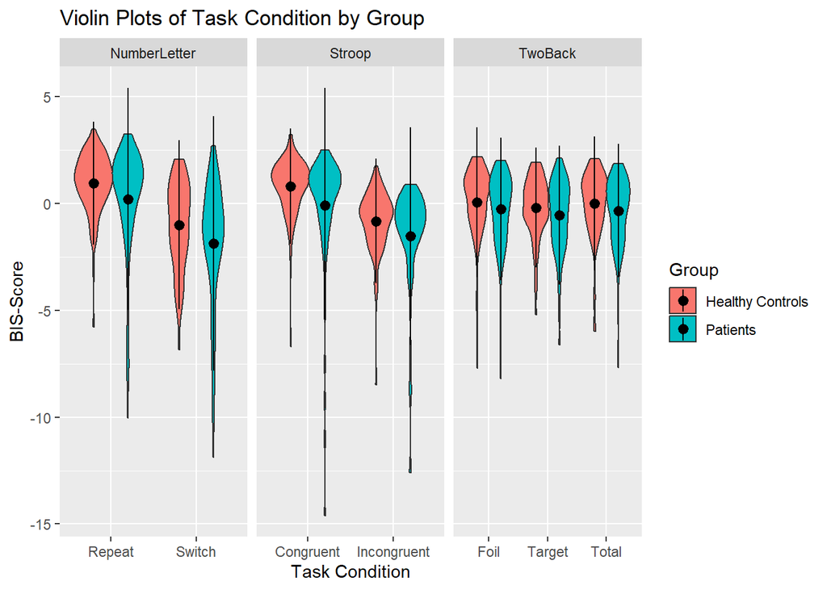

```r
print(violin_plots_patients_hc)
```

### Comparison patients pre vs. post

```r
# Reshape data from wide to long format
Patients_pre_vs_post_long <- Patients_pre_vs_post_imp %>%
  pivot_longer(cols = all_of(BIS_columns_renamed),
               names_to = "Condition",
               values_to = "BIS_Score")

# Add new task variable
Patients_pre_vs_post_long <- Patients_pre_vs_post_long %>%
  mutate(Task = case_when(
    grepl("NumberLetter", Condition) ~ "NumberLetter",
    grepl("Stroop", Condition) ~ "Stroop",
    grepl("TwoBack", Condition) ~ "TwoBack"
  ))

# Remove prefixes from Condition labels, keeping Task intact
Patients_pre_vs_post_long <- Patients_pre_vs_post_long %>%
  mutate(Condition = gsub("NumberLetter_BIS_|Stroop_BIS_|TwoBack_BIS_", "", Condition))

# Convert "time" to factor, specify order
Patients_pre_vs_post_long$time <- factor(Patients_pre_vs_post_long$time, levels = c("pre", "post"))

# Create boxplot with paired observations
boxplot_Patients_pre_post <- ggplot(Patients_pre_vs_post_long, aes(x = Condition, y = BIS_Score, color = time)) + # group = Subject
  geom_boxplot(outlier.shape = NA) +
  geom_jitter(position = position_jitterdodge(),
              size = 0.7,
              shape = 21,
              fill = NA) +
  #geom_line(aes(group = Subject)) +
  facet_wrap(~ Task, scales = "free_x") +
  labs(title = "Boxplots of Task Condition by Time of Measurement",
       x = "Condition",
       y = "BIS-Score",
       color = "Time")
```

### Boxplot for Patients pre vs. post intervention

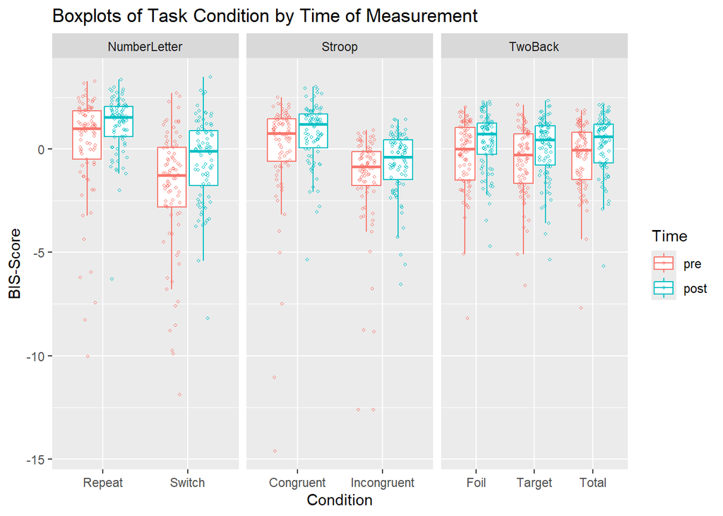

```r
print(boxplot_Patients_pre_post)
```